# Binomial Function Starter Kit

Shivansh Kumar

2019-04-28

## Binomial Distribution Package Starter Kit

The **binomial** package implements different functions and methods that calculate and display different summary measures of different binomial objects. There are also functions that can be used to create a binomial object that can be used to find the probability of success based on different parameter values that describe this binomial function.

## Getting Started with Binomial Package

Load the binomial package and other required packages into the workspace with the code below:

```r
library(binomial)
library(ggplot2)
```

In the binomial package, there are some *main functions* that can be used to describe different binomial distributions with examples on how to use.

1. **bin_choose**: Binomial choose function that computes the number of combinations in which `k` successes can occur in `n` trials.

```r
bin_choose(n = 10, k = 5)
```

```
#> [1] 252
```

2. **bin_probability**: Binomial probability function that computes the probability of getting `k` successes in `n` trials with probability of success `prob`.

```r
bin_probability(success = 2, trials = 5, prob = 0.5)
```

```
#> [1] 0.3125
```

3. **bin_distribution**: Binomial distribution function that creates a binomial distribution data frame using the binomial probability function with successes and probabilities as columns.

```r
bin_distribution(trials = 5, prob = 0.5)
```

```
#>   success probability
#> 1       0     0.03125
#> 2       1     0.15625
#> 3       2     0.31250
#> 4       3     0.31250
#> 5       4     0.15625
#> 6       5     0.03125
```

Method used with `bin_distribution` function that graphs barplot to display probability histogram of binomial distribution object “bindis”:

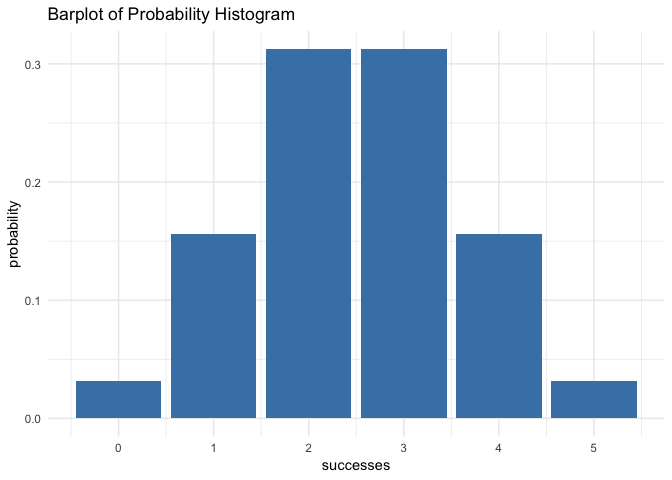

```r
dis1 <- bin_distribution(trials = 5, prob = 0.5)
plot(dis1)
```

4. **bin_cumulative**: Binomial cumulative function that creates a binomial distribution data frame using the binomial probability function with successes, probabilities, and cumulative probabilities as columns.

```r
bin_cumulative(trials = 5, prob = 0.5)
```

```
#>   success probability cumulative
#> 1       0     0.03125    0.03125
#> 2       1     0.15625    0.18750
#> 3       2     0.31250    0.50000
#> 4       3     0.31250    0.81250
#> 5       4     0.15625    0.96875
#> 6       5     0.03125    1.00000
```

Method used with `bin_cumulative` function that graphs the cumulative distribution of binomial distribution object “bincum”:

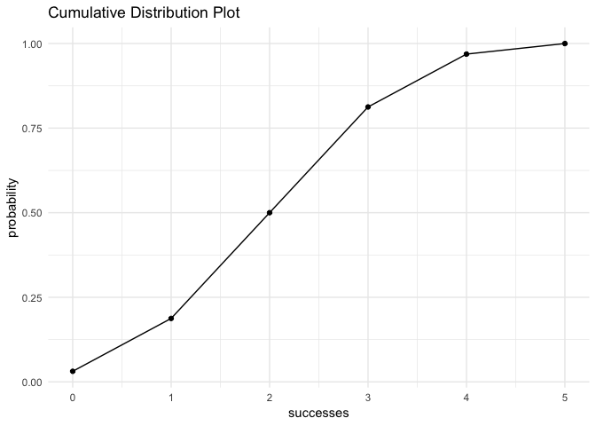

```r
dis2 <- bin_cumulative(trials = 5, prob = 0.5)
plot(dis2)
```

5. **bin_variable**: Binomial random variable function that returns an object of class “binvar” that is a binomial random variable object.

```r
bin_variable(trials = 5, prob = 0.5)
```

```
#> "Binomial variable"
#>
#> Parameters
#> - number of trials:  5
#> - prob of success:  0.5
```

```r
bin1 <- bin_variable(trials = 10, p = 0.3)
bin1
```

```
#> "Binomial variable"
#>
#> Parameters
#> - number of trials:  10
#> - prob of success:  0.3
```

Method used with `bin_variable` function that gives the full summary description of an object “binvar”:

```r
bin1 <- bin_variable(trials = 10, p = 0.3)
summary(bin1)
```

```
#> "Summary Binomial"
#>
#> Parameters
#> - number of trials:  10
#> - prob of success:  0.3
#>
#> Measures
#> - mean    :  3
#> - variance:  2.1
#> - mode    :  3
#> - skewness:  0.2760262
#> - kurtosis:  -0.1238095
```

Method used with `bin_variable` function and summary method that prints the summary.binvar object:

```r
bin1 <- bin_variable(trials = 10, p = 0.3)
binsum1 <- summary(bin1)
binsum1
```

```
#> "Summary Binomial"
#>
#> Parameters
#> - number of trials:  10
#> - prob of success:  0.3
#>
#> Measures
#> - mean    :  3
#> - variance:  2.1
#> - mode    :  3
#> - skewness:  0.2760262
#> - kurtosis:  -0.1238095
```

** Summary Measures Descriptions **

1. *Mean* = $np$
2. *Variance* = $np(1 - p)$
3. *Mode* = $int(np + p)$
4. *Skewness* = $\frac{1 - 2p}{\sqrt{np(1 - p)}}$
5. *Kurtosis* = $\frac{1 - 6p(1 - p)}{np(1 - p)}$

Can also directly calculate these summary measures using functions below:

```r
bin_mean(10, 0.3)
```

```
#> [1] 3
```

```r
bin_variance(10, 0.3)
```

```
#> [1] 2.1
```

```r
bin_mode(10, 0.3)
```

```
#> [1] 3
```

```r
bin_skewness(10, 0.3)
```

```
#> [1] 0.2760262
```

```r
bin_kurtosis(10, 0.3)
```

```
#> [1] -0.1238095
```

## Extra Help

If need more documentation, can call the help function on any of the functions described above in this vignette.

Example for calling help function on bin_choose:

```r
help(bin_choose)
```